# Xerces Project Final Summary

## Introduction

“The Xerces Society for Invertebrate Conservation is an international nonprofit organization that protects the natural world through the conservation of invertebrates and their habitats” (Mission & History). The name Xerces is based off an extinct butterfly, Xerces Blue. This extinction was the first known in North America due to human activities. “The Xerces Society’s core programs focus on habitat conservation and restoration, species conservation, protecting pollinators, contributing to watershed health, and reducing harm to invertebrates from pesticide use” (Mission & History).

The Eureka team is focusing on the data from the Xerces Society Pollinator Conservation Program. The core focus of Pollinator Conservation Program is conserving the pollinators’ habitats and attracting native pollinators. “The ecological service they provide is necessary for the reproduction of over 85% of the world’s flowering plants, including more than two-thirds of the world’s crop species” (Pollinator Conservation). The impact of losing pollinators is monumental not to just humans but to animal life as well. “The economic value of these native pollinators is estimated at $3 billion per year in the U.S” (Pollinator Conservation). Therefore, not only would food from crops be in ruin but food obtained from most animals would be ruined as well. The main threats to these pollinators are habit loss, pesticide use, and introduced diseases.

## The Project Data

The visit data contained a field ID, a visit ID, Transect, the visit date, the observer, the surrounding Landscape and the Notes about the visit. Much of the data for the surrounding landscape is duplicated for each transect and each visit. The notes cells have the missing data for this sheet. The notes also contain an indication if the site failed. Another indication of a failed site was a fall visit did not occur. The Surrounding Landscape and the Notes columns were free text fields and difficult to parse. The Surrounding Landscape data has the potential to add value though. As a result, this data was parsed manually into a new dataset. The team received 56 rows of visit data.

The veg or vegetation data contained a Visit ID, a species and 20 quadrat columns divided by floral cover and non-floral cover. The quadrat contains a number from 1 to 6 that translates to the amount of coverage for that species within the quadrat. Much of this data is blank but not missing which is to be expected. The team received 891 rows of veg data. The macro data set contained a Visit ID, 3 columns that categorizes the species cover in the macroplots, <1%, 1-5% and > 5%, and Notes. The Notes are free form text. Much of this data is blank but not missing which is to be expected. The team received 650 rows of macro data.

The seed data set contained a Field ID, Species, Pure Live Seed lbs per acre and Origin. This data set contains no missing data. The sum of the Pure Live Seed pound per acre by Field ID data matches the value found for that Field ID in the Site data sheet. The team received 543 rows of seed data. The final data was the Species Attribute data set. This data set contained Species, Coefficient of Conservatism and common Name. A significant portion of the Coefficient of Conservatism is marked with an asterisk. These species will not be included in any coefficient of conservation averages per the client. The team received 182 rows of Species Attribute data.

## Data Cleaning Process

The team used the data in the spreadsheet and used it to form a few other data sets. The first new data set, we called expandedSiteData. This data set has the site data, visit data and the new manually parsed surrounding landscaping data. The surrounding landscaping data was parsed into 7 new columns, LandSTree, LandSRoad, LandSStructures, LandSSCrop, LandSGrass, LandSWaterArea, and LandSOther. The success or failure from the notes column was added to a new column called Established. The columns not included in the new data set were Visit ID, Observer, Visit Date, Surrounding LandScape and Notes columns.

The team also expanded the Species Attributes data set by adding taxonomy data. This addition was done in an effort to collapse the species data without losing essential meanings and making it easier to work with. This task allowed us to reduce more than 700 rows of data into 1 row of data, the order associated with the more than 700 species. The team also looked at the veg data for ways to format it so that we could increase our success with analysis. We decided to deconstruct it. We took 22 columns and constructed a new data set that was longer but not as wide. Instead of 22 columns, the data set had 4 columns, Visit ID, Species, quadrat. This data set was also combined with data from the visit data set as well as the site data set.

During the data cleaning process, we also looked at the data process within the data sets that we received. There were a couple of issues that we needed to correct. First, we assumed that any column without data was not missing data. The team felt that the nature of the data would lead to much data being blank. We decided that this data could be ignored especially when looking at the seed data for the Quadrat.Second, we corrected some consistency issues across the data set like Site Gage11018 was labeled as Gage11018A in the visit data. This update was done for Harlan11007 & Harlan11008 as well.

## Research Questions

The team decided that we would use the data to evaluate 4 research questions

1. How has the variables associated with the site contributed to the success or failure of the site?
2. How does the factor of being native versus non-native affect the plant growth of species in the fields tested?
3. Do certain plant families show a greater cover value than others plant families?
4. Does the average Coefficient of Conservatism of the species planted in each field contribute to the success of failure of the field?

### Research Question 1

#### How has the variables associated with the site contributed to the success or failure of the site?

The sites are situated in three regions within Nebraska. The regions are South Central (SC), North East (NE) and South East (SE). The sites distributed evenly between the regions. There are five sites in the North East, seven sites in the South Central and five sites in the South East region. Most Regions had sites in multiple counties except for the North East where all of the sites were in the same county. The number of acres per site does vary. Some sites that are just over one acre like the Johnson County site 110261 in the Southeastern part of Nebraska. While the largest site 11008 in South Central Nebraska in Furnas County is nearly 45 acres.

When tackling the question of what variables could have contributed to the success or failure of a site, we should look at where the site was located. Eighty percent of the sites in Antelope County in the North East region failed. The failed sites in Antelope county received seed mixes from two vendors and those vendors did not supply seed to any other site. All of the failed sites plantings occurred in the spring. The Pure Live Seed per acre, which indicates the amount of seed in the lot that is capable of developing into seedlings, is significantly lower than what was planted at the majority of the successful sites.

### Research Question 2

#### How does the factor of being native versus non-native affect the plant growth of species in the fields tested?

Coverage Value is a number assigned to a scale of the percentage of the Quadrant covered by the plant.  
1 – < 5%  
2 – 5 - 25%  
3 – 26 - 50%  
4 – 51 - 75%  
5 – 76 - 95%  
6 – > 99%.

#### Multi-Plot of Density per Floral Cover

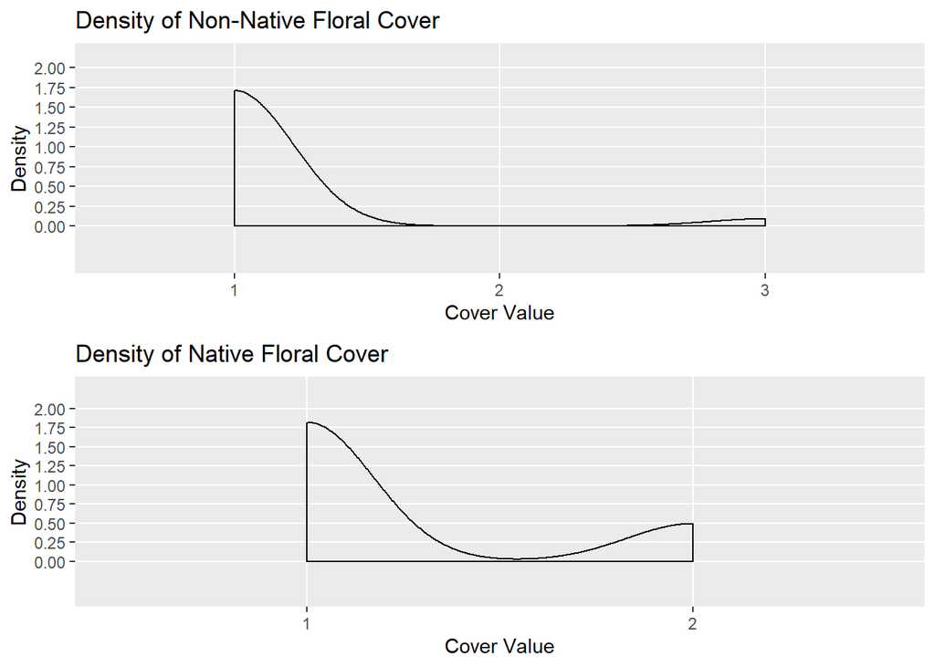

This plot is a side-by-side look at the Floral Coverage of native vs non-native plant species. It shows the differences in how often they had cover values of 1-3. 4-6 was never hit so the graph was shrunk to 3. Native plants species had a higher density at 1 and 2 but had no values of 3 recorded. The differences at the value of 1 is small but could mean native plants have a higher chance to start up.

#### Multi-Plot of Density for Plant Species Cover

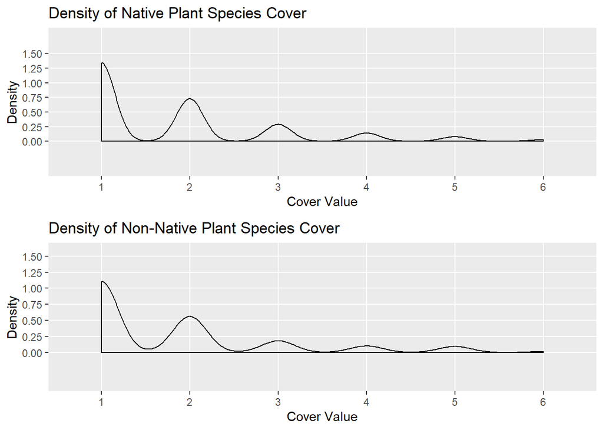

This plot is a side-by-side look at the Plant Species Coverage of native vs non-native plant species. The plant species coverage is a measure of how established the plant is within a quadrant. The higher the value the better the growth. The plots show that the native plants have a higher density in the coverage values 1:4. This is showing that the early establishment of native plants is stronger than non-native plants. Values 5 and 6 show very similar densities between native and non-native plant species but the density is very small for each.

### Reasearch Question 3:

#### Do certain plant families show a greater cover value than others plant families?

#### Density of Floral Cover by Plant Family

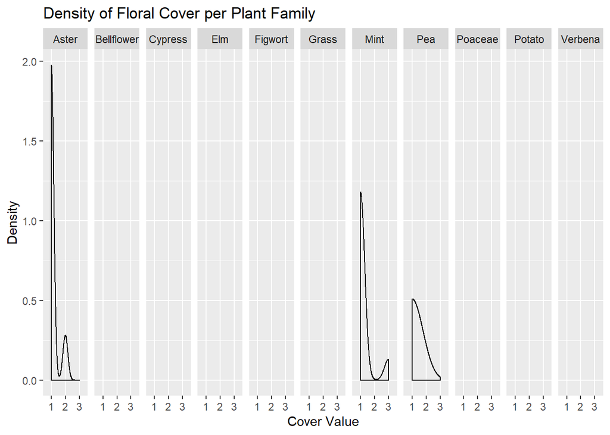

This plot shows that many of the families did not have much data in regards to Floral Coverage. The Aster, Mint, and Pea families were the only ones with recorded data. There is not many conclusions to be drawn from this plot. It is shown that the Aster and Mint family are recorded very highly at the value of 1, which indicates they started growing well, even if only covering a small amount. The Pea family while having less density at the value of 1, has the largest density of 2. The Mint family was the highest at 3, meaning it covered the most amount of the quadrat of any plant family measured by floral coverage.

#### Density of Plant Species Cover per Plant Family

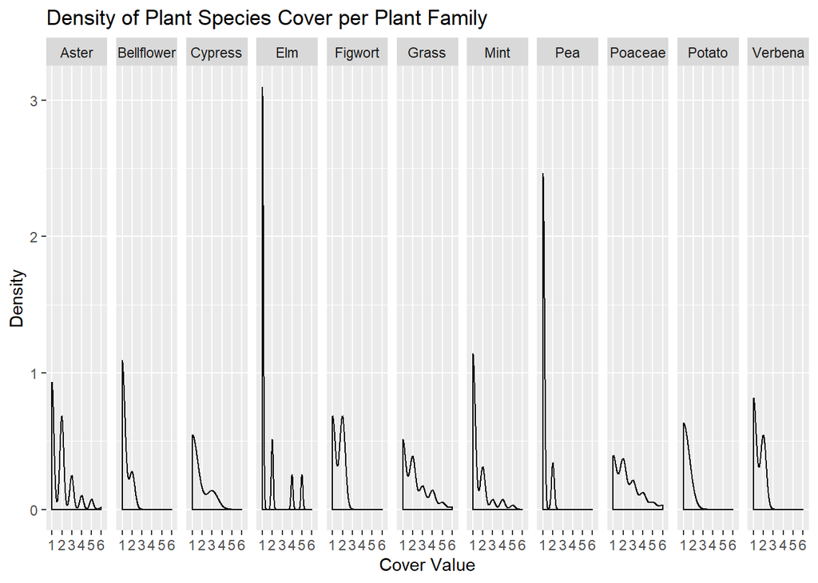

This plot shows each plant families density of cover data in regards to Plant Species Coverage. Bellflower, Figwort, Pea, Potato, and Verbena show very small, if any density past the Cover Value of 3. This means that the did not grow to cover as much of the quadrat as some of the other families did. Aster, Grass, and Poaceae families showed the highest densities at 6, the top cover value. This means that these families had the highest coverage of their quadrants.

### Research Question 4:

#### Does the average Coefficient of Conservatism of the species planted in each field contribute to the success of failure of the field?

The coefficient of the conservatism is a range from 0 - 10 and represent an estimated probability that a plant is likely to occur in a landscape relatively unaltered from what is believed to be pre-European settlement condition. For example, common weedy species would have 0 or low C values, they move into new habitats readily while a rare orchid species may have a C value of 10 – it needs very specific conditions to thrive.

Table 1: Average Coefficient of Conservatism by Site for Native Plants

| Field ID | avg Coefficient Conservatism | Established |
| --- | --- | --- |
| Antelope11001 | 2.600 | Failure |
| Antelope11002 | 3.111 | Failure |
| Antelope11005 | 1.862 | Success |
| Antelope11025A | 1.182 | Failure |
| Antelope11025B | 2.345 | Failure |
| Furnas11006 | 2.988 | Success |
| Furnas11008 | 2.315 | Success |
| Gage11018 | 2.933 | Success |
| Gage11054 | 3.228 | Success |
| Gage11060 | 3.166 | Success |
| Harlan11007 | 2.840 | Success |
| Harlan11008 | 1.167 | Failure |
| Harlan11012 | 3.779 | Success |
| Johnson110261 | 2.744 | Success |
| Johnson110262 | 2.089 | Success |
| Webster11004 | 3.661 | Success |
| Webster11006 | 0.074 | Failure |

Table 1 shows the average coefficient of conservatism for each site along with the status of the site, whether is was successful or not. The graph below shows the distribution of the species across the coefficient of Conservatism.

#### Distribution of Species across the Coefficient of Conservatism within each site

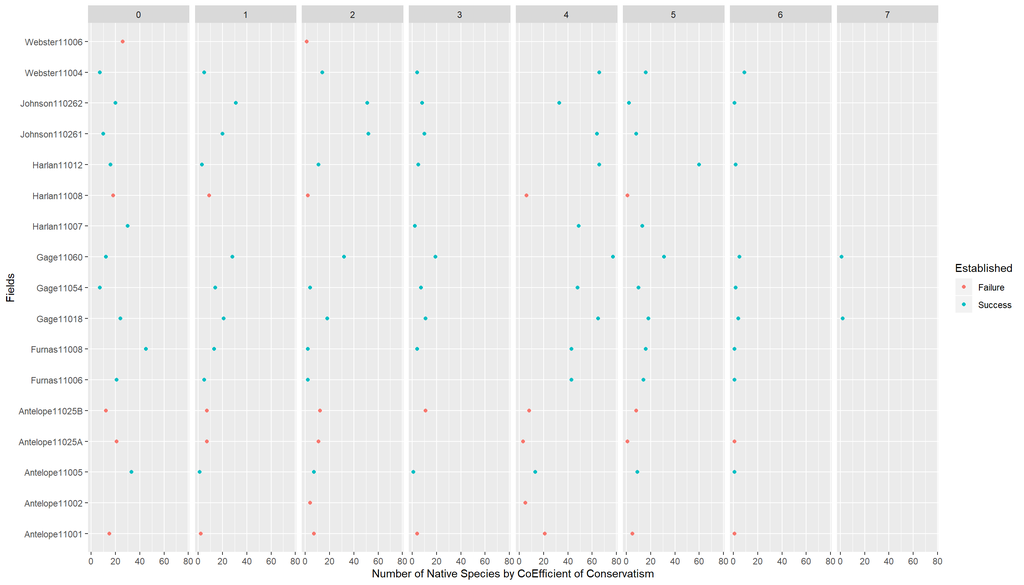

The distribution of the species over the range of the coefficient of conservatism for the failed sites seems comparable to the sites that were successful. However, the amount of each species for the failed sites represented in each range is lower than in the amounts in the successful sites. As for the successful sites, there seems to be a significant concentration of species present in the 4 and 5 range of the coefficient of conservation. On a whole the successful sites have a stronger presence of species across all of the ranges shown.

## Conclusion

We examined several aspects of the data during this project. We looked at a variety of variables affecting the sites. We looked at where the site was situated, the seed vendors providing the seed to the site, the amount of good seed provided to a site known as the PLS per acre and the landscape surrounding the sites. Looking at these variables, we could say the Seed Vendors was a source of success for a site. We found that two seed vendors provided seed for four of the failing sites and none of the successful sites. The amount of good seed provided by these two vendors was lower than we saw with the other vendors associated with the successful sites.

We looked at Native plants verses Non-native plants. We saw that native plants recorded a higher density with early establishment over non-native plants. When we looked at plant family, we did not see much data as it related to the cover value associated with floral plants by family. However, coverage of plant species within the families of Aster, Grass and Poaceae showed the highest densities of a 6-cover value. Lastly, we saw coefficient of conservatism ranges up to 7-cover value throughout the sites. The failed site as expected had a small number of species throughout the ranges. We saw heavy concentrations within the 4-cover value and 5-cover value range for successful sites.